# Multiple imputation of missing data with mice

Jerry Reiter

Example by Jerry Reiter for short course at Odum Institute, March 2018. This short example shows R commands for handling missing data using the `mice` package.

## Preliminaries (load packages and data)

*If you have not already, install the mice package with the following command (remove #):*

```r
#install.packages("mice")
```

Once you have `mice` installed, load it into memory using the command:

```r
library(mice)
```

We illustrate the package with a simple data set from the mice package:

```r
data(nhanes2)

dim(nhanes2)
```

```
## [1] 25  4
```

```r
summary(nhanes2)
```

```
##     age          bmi          hyp          chl
##  20-39:12   Min.   :20.40   no  :13   Min.   :113.0
##  40-59: 7   1st Qu.:22.65   yes : 4   1st Qu.:185.0
##  60-99: 6   Median :26.75   NA's: 8   Median :187.0
##             Mean   :26.56             Mean   :191.4
##             3rd Qu.:28.93             3rd Qu.:212.0
##             Max.   :35.30             Max.   :284.0
##             NA's   :9                 NA's   :10
```

Note that the `age` and `hyp` variables are already defined as factor variables in this dataset. If you have a dataset with categorical variables without this pre-definition, you should make the variables factors before doing mice. For example, to make a variable called *var1* into a factor in some dataset called *thedata*, type `thedata$var1 = as.factor(thedata$var1)`.

## Missing data

The `NA` values represent missing data.

Let’s look at the missing data pattern:

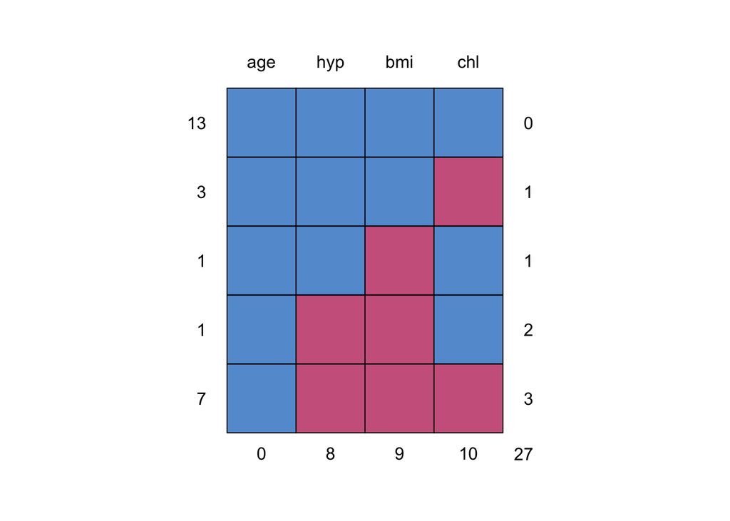

```
##    age hyp bmi chl
## 13   1   1   1   1  0
## 3    1   1   1   0  1
## 1    1   1   0   1  1
## 1    1   0   0   1  2
## 7    1   0   0   0  3
##      0   8   9  10 27
```

```r
md.pattern(nhanes2)
```

## Exploratory data analyses

Let’s look at some exploratory data analyses based on the complete cases.

First make the complete cases

```r
ccnhanes2data = cc(nhanes2)
ccnhanes2data
```

```
##      age  bmi hyp chl
## 2  40-59 22.7  no 187
## 5  20-39 20.4  no 113
## 7  20-39 22.5  no 118
## 8  20-39 30.1  no 187
## 9  40-59 22.0  no 238
## 13 60-99 21.7  no 206
## 14 40-59 28.7 yes 204
## 17 60-99 27.2 yes 284
## 18 40-59 26.3 yes 199
## 19 20-39 35.3  no 218
## 22 20-39 33.2  no 229
## 23 20-39 27.5  no 131
## 25 40-59 27.4  no 186
```

Note that there are only 3 cases with `hypertension = yes`. Relationships will be hard to model accurately due to small sample size…

We will use these data for illustration of the MI procedures. Really we need more data to say anything meaningful about relationships among these variables.

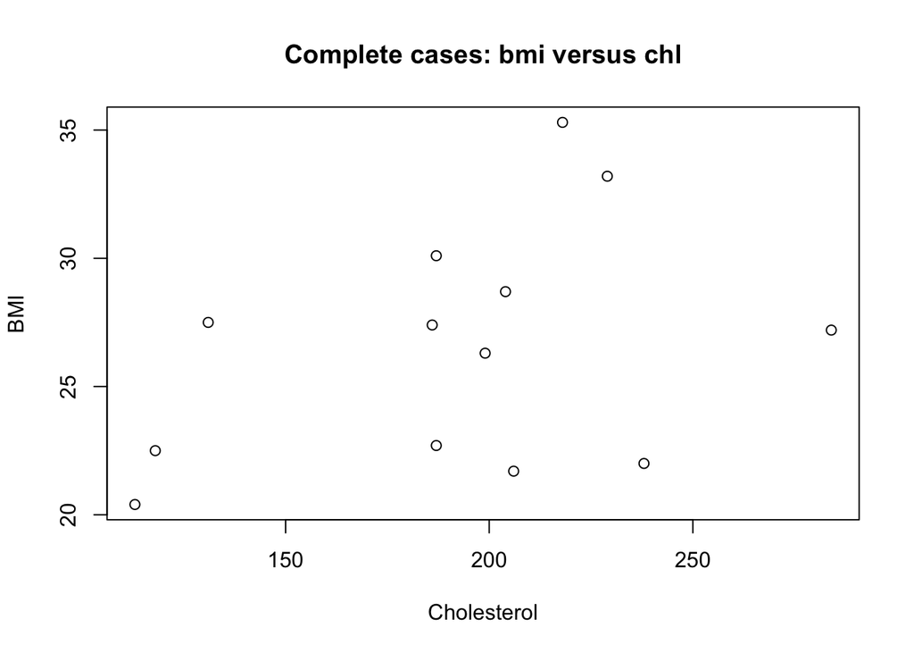

```r
plot(ccnhanes2data$bmi, x=ccnhanes2data$chl, xlab = "Cholesterol", ylab = "BMI", main = "Complete cases: bmi versus chl")
```

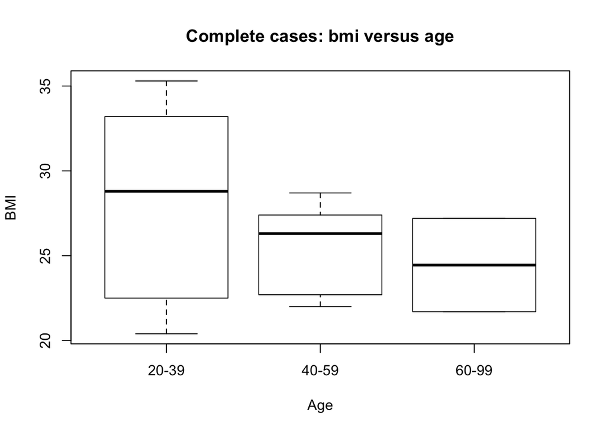

```r
boxplot(ccnhanes2data$bmi ~ ccnhanes2data$age, xlab = "Age", ylab = "BMI", main = "Complete cases: bmi versus age")
```

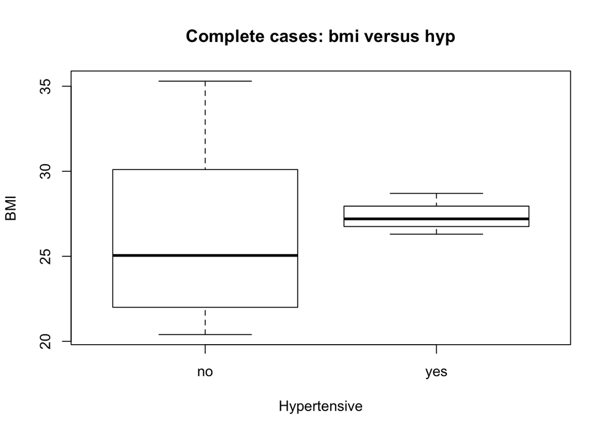

```r
boxplot(ccnhanes2data$bmi ~ ccnhanes2data$hyp, xlab = "Hypertensive", ylab = "BMI", main = "Complete cases: bmi versus hyp")
```

## Multiple imputation

### How to use `mice`

Let’s create 5 multiple imputations for the missing values. We will use normal linear regressions for continuous variables, logistic regressions for binary variables, multinomial regressions for unordered categorical variables, and proportional odds models for ordered categorical variables. *Note: We have not discussed the last two models in this class, but they are popular models for these kinds of data.*

```r
nhanes2MI5 = mice(nhanes2, m=5, defaultMethod = c("norm", "logreg", "polyreg", "polr"))
```

Look at the first couple of completed datasets

```r
d1 = complete(nhanes2MI5, 1)
d1
```

```
##      age      bmi hyp       chl
## 1  20-39 27.10510  no 178.72730
## 2  40-59 22.70000  no 187.00000
## 3  20-39 27.85599  no 187.00000
## 4  60-99 31.65444 yes 321.80262
## 5  20-39 20.40000  no 113.00000
## 6  60-99 18.55172  no 184.00000
## 7  20-39 22.50000  no 118.00000
## 8  20-39 30.10000  no 187.00000
## 9  40-59 22.00000  no 238.00000
## 10 40-59 23.79742  no 150.99083
## 11 20-39 18.36895  no  81.90879
## 12 40-59 19.17256  no 159.52815
## 13 60-99 21.70000  no 206.00000
## 14 40-59 28.70000 yes 204.00000
## 15 20-39 29.60000  no 187.43072
## 16 20-39 29.57671  no 166.30587
## 17 60-99 27.20000 yes 284.00000
## 18 40-59 26.30000 yes 199.00000
## 19 20-39 35.30000  no 218.00000
## 20 60-99 25.50000 yes 271.85660
## 21 20-39 26.56711  no 154.82231
## 22 20-39 33.20000  no 229.00000
## 23 20-39 27.50000  no 131.00000
## 24 60-99 24.90000  no 231.30378
## 25 40-59 27.40000  no 186.00000
```

```r
d2 = complete(nhanes2MI5, 2)
d2
```

```
##      age      bmi hyp       chl
## 1  20-39 32.93049  no 183.58290
## 2  40-59 22.70000  no 187.00000
## 3  20-39 31.09278  no 187.00000
## 4  60-99 18.87489  no 195.42848
## 5  20-39 20.40000  no 113.00000
## 6  60-99 15.20205 yes 184.00000
## 7  20-39 22.50000  no 118.00000
## 8  20-39 30.10000  no 187.00000
## 9  40-59 22.00000  no 238.00000
## 10 40-59 28.12083  no 227.16156
## 11 20-39 26.44805  no 185.25915
## 12 40-59 29.50729  no 219.47739
## 13 60-99 21.70000  no 206.00000
## 14 40-59 28.70000 yes 204.00000
## 15 20-39 29.60000  no 185.81944
## 16 20-39 20.44892  no  84.21949
## 17 60-99 27.20000 yes 284.00000
## 18 40-59 26.30000 yes 199.00000
## 19 20-39 35.30000  no 218.00000
## 20 60-99 25.50000 yes 250.17108
## 21 20-39 23.73500  no 118.28273
## 22 20-39 33.20000  no 229.00000
## 23 20-39 27.50000  no 131.00000
## 24 60-99 24.90000  no 237.60771
## 25 40-59 27.40000  no 186.00000
```

### Imputation diagnostics

Plot imputed and observed continuous variables

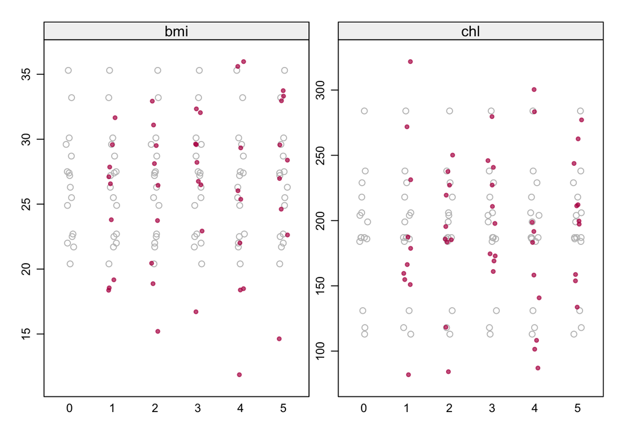

```r
stripplot(nhanes2MI5, col=c("grey",mdc(2)),pch=c(1,20))
```

Grey dots are observed values and red dots are imputed values. There is no evidence of problematic imputations for these variables.

If you just want to see one continuous variable, say `bmi`, use:

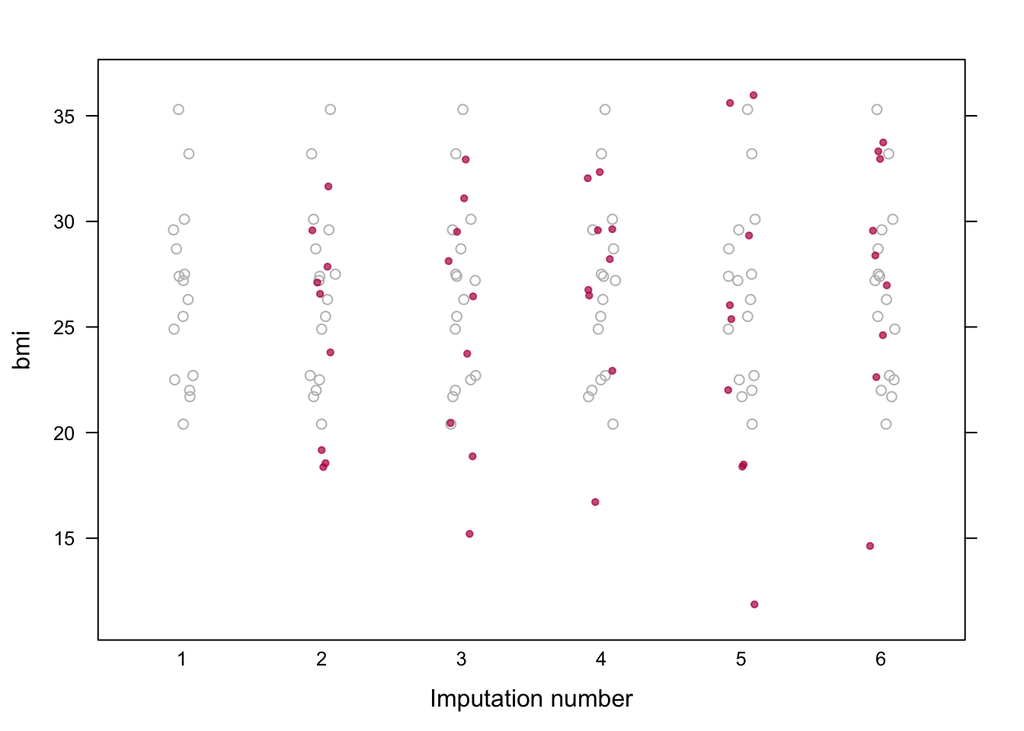

```r
stripplot(nhanes2MI5, bmi~.imp, col=c("grey",mdc(2)),pch=c(1,20))
```

Also you can do plots by values of categorical variable, say `bmi` by `age` grouping:

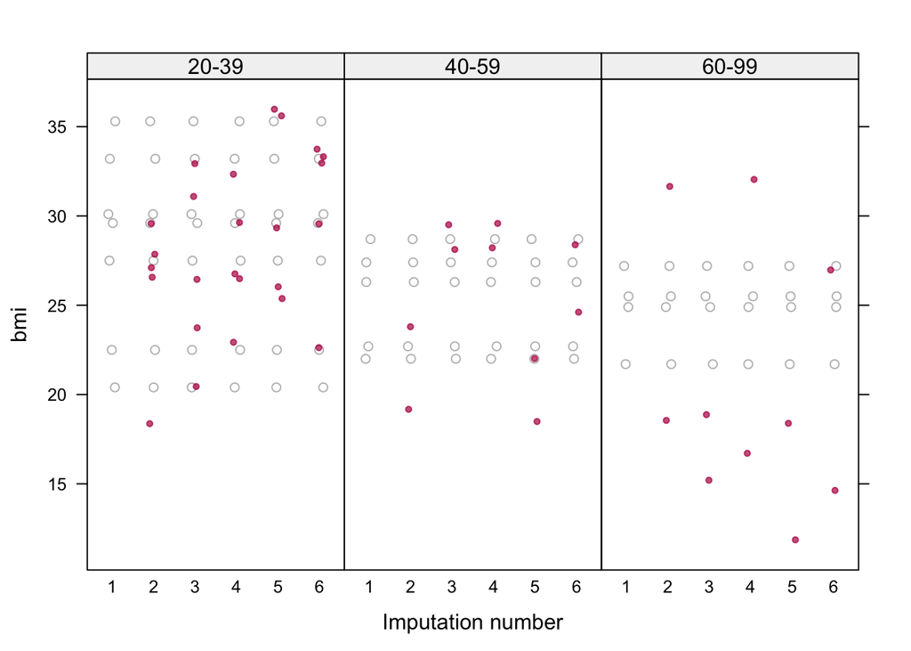

```r
stripplot(nhanes2MI5, bmi~.imp|age, col=c("grey",mdc(2)),pch=c(1,20))
```

And also you can plot all the imputations in one plot to see relationships:

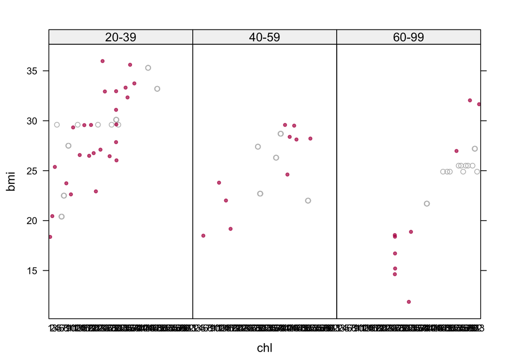

```r
stripplot(nhanes2MI5, bmi~chl|age, col=c("grey",mdc(2)),pch=c(1,20))
```

**Scatter plots** of `bmi` and `chl` by `age`:

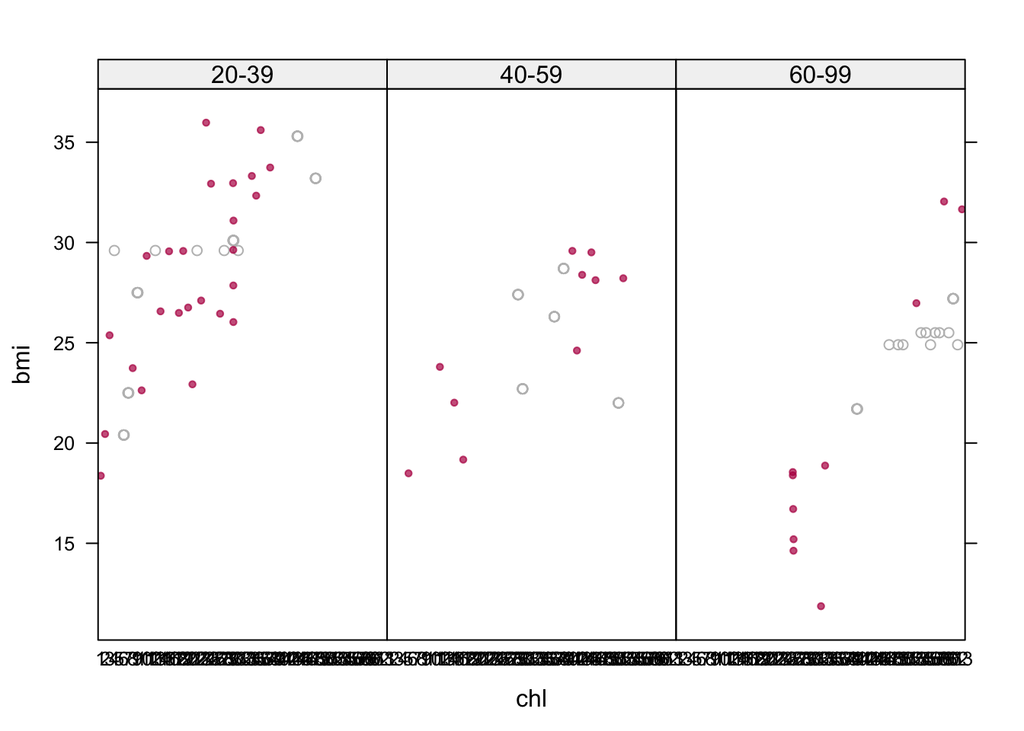

```r
stripplot(nhanes2MI5, bmi~chl|age, col=c("grey",mdc(2)),pch=c(1,20))
```

**Dot plots** of `bmi` by `hyp` by `age`:

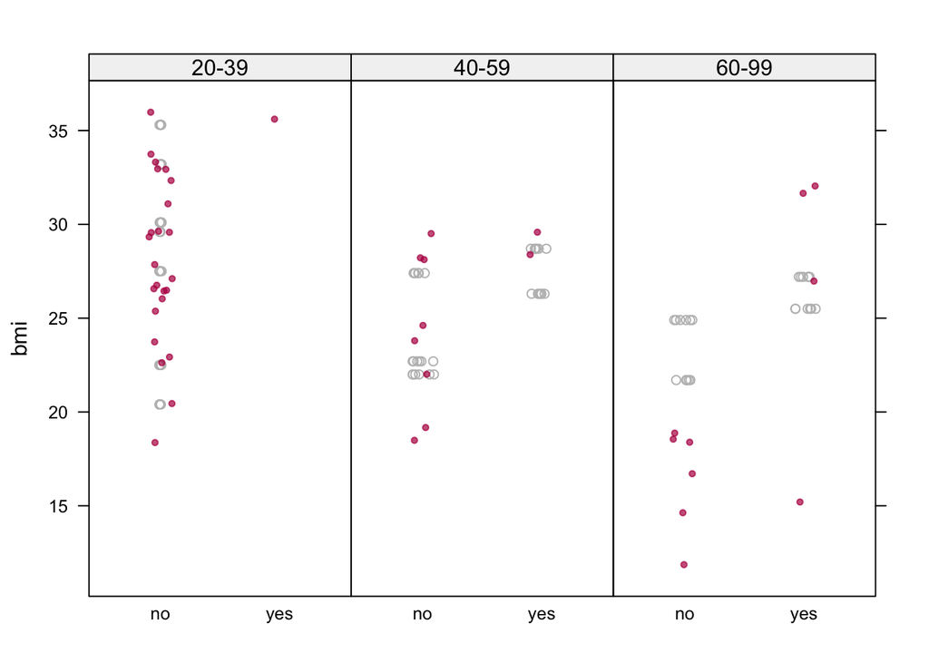

```r
stripplot(nhanes2MI5, bmi~hyp|age, col=c("grey",mdc(2)),pch=c(1,20))
```

There are no obvious problems with the imputations from these plots.

You can also try **posterior predictive checks**. Let’s append the data and make replicates:

```r
nhanes2ppcheck = rbind(nhanes2, nhanes2)
#check to make sure we've done what we intended
nhanes2ppcheck
```

```
##       age  bmi  hyp chl
## 1   20-39   NA <NA>  NA
## 2   40-59 22.7   no 187
## 3   20-39   NA   no 187
## 4   60-99   NA <NA>  NA
## 5   20-39 20.4   no 113
## 6   60-99   NA <NA> 184
## 7   20-39 22.5   no 118
## 8   20-39 30.1   no 187
## 9   40-59 22.0   no 238
## 10  40-59   NA <NA>  NA
## 11  20-39   NA <NA>  NA
## 12  40-59   NA <NA>  NA
## 13  60-99 21.7   no 206
## 14  40-59 28.7  yes 204
```

[output cut: 36 more lines]

Now blank every value in 3 variables with missing values:

```r
nhanes2ppcheck[26:50, 2:4] = NA
nhanes2ppcheck
```

```
##       age  bmi  hyp chl
## 1   20-39   NA <NA>  NA
## 2   40-59 22.7   no 187
## 3   20-39   NA   no 187
## 4   60-99   NA <NA>  NA
## 5   20-39 20.4   no 113
## 6   60-99   NA <NA> 184
## 7   20-39 22.5   no 118
## 8   20-39 30.1   no 187
## 9   40-59 22.0   no 238
## 10  40-59   NA <NA>  NA
## 11  20-39   NA <NA>  NA
## 12  40-59   NA <NA>  NA
## 13  60-99 21.7   no 206
## 14  40-59 28.7  yes 204
```

[output cut: 36 more lines]

Run the MI software on the completed data:

```r
nhanes2MI5ppcheck = mice(nhanes2ppcheck, m=5, defaultMethod = c("norm", "logreg", "polyreg", "polr"))
```

Get the completed datasets – in the interest of time look at first two datasets:

```r
d1ppcheck = complete(nhanes2MI5ppcheck, 1)
d2ppcheck = complete(nhanes2MI5ppcheck, 2)
```

Let’s graph **histograms** of `bmi` for each of the datasets:

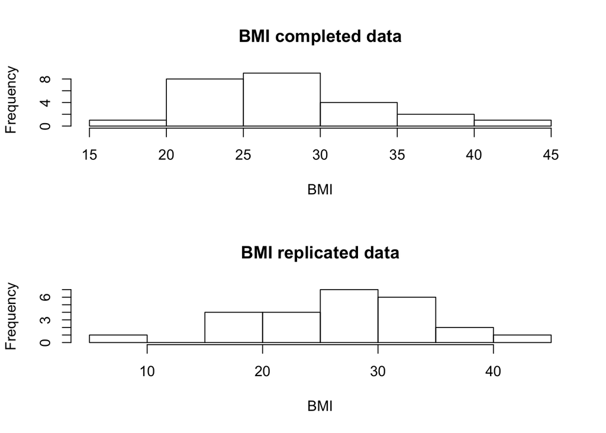

```r
par(mfcol=c(2,1))
hist(d1ppcheck$bmi[1:25], xlab = "BMI", main = "BMI completed data")
hist(d1ppcheck$bmi[26:50], xlab = "BMI", main = "BMI replicated data")
```

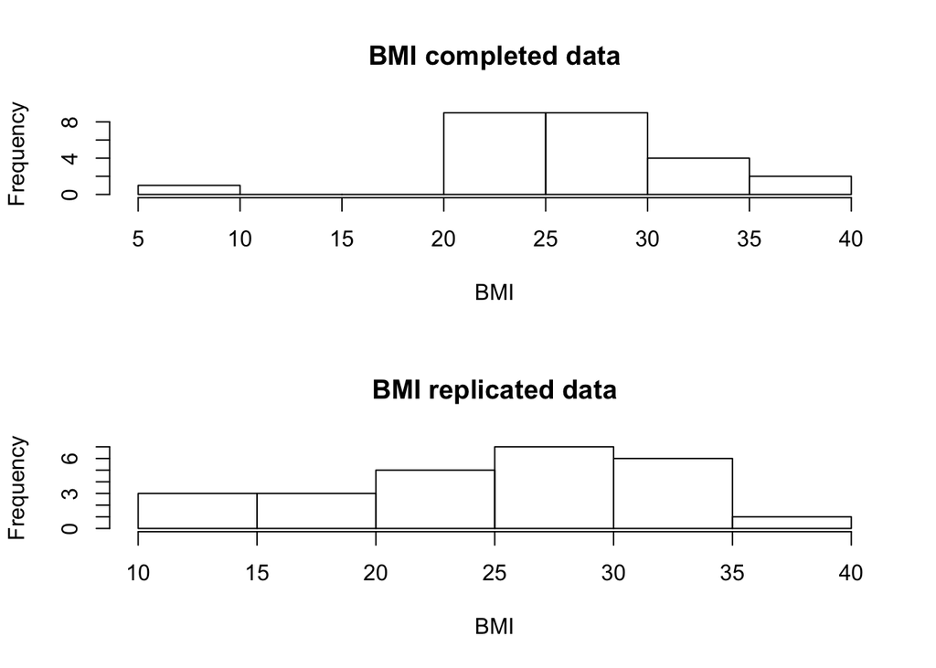

```r
hist(d2ppcheck$bmi[1:25], xlab = "BMI", main = "BMI completed data")
hist(d2ppcheck$bmi[26:50], xlab = "BMI", main = "BMI replicated data")
```

You can also use **scatter plots** to check relationship between variables:

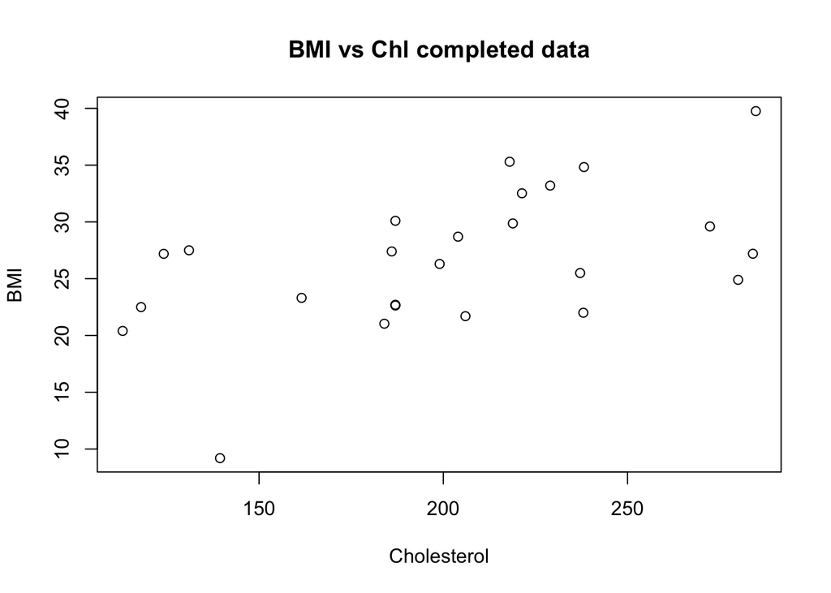

```r
plot(d2ppcheck$bmi[1:25]~d2ppcheck$chl[1:25], ylab = "BMI", xlab = "Cholesterol", main = "BMI vs Chl completed data")
```

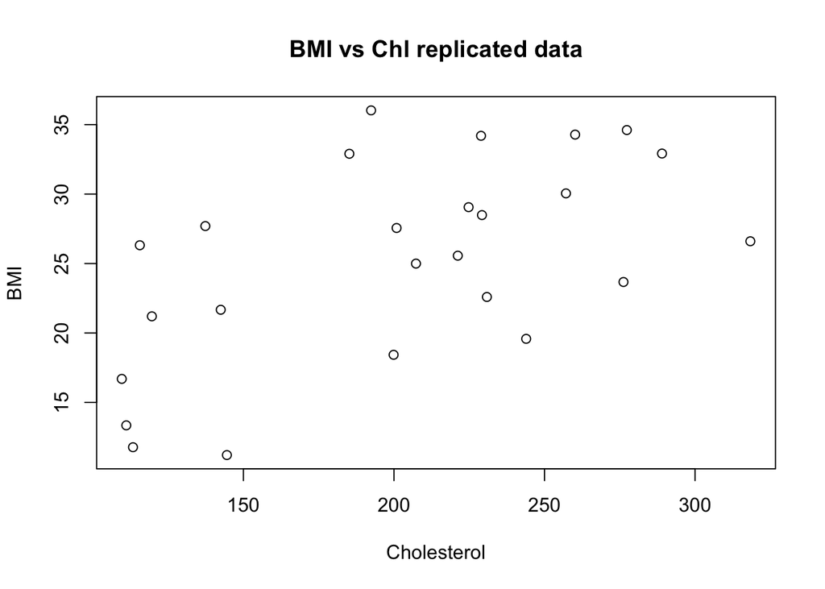

```r
plot(d2ppcheck$bmi[26:50]~d2ppcheck$chl[26:50], ylab = "BMI", xlab = "Cholesterol", main = "BMI vs Chl replicated data")
```

Looks pretty similar! No evidence that imputation models are poorly specified for what we want to do.

## Inference using the completed datasets

To do **model specification**, i.e., transformations, either look at the complete cases or use one of the completed datasets. For example, to use the first dataset `d1` in a regression of `bmi` on `age`, `hyp` and `chl`, use:

```r
bmiregd1 = lm(bmi~age+hyp+chl, data = d1)
```

To check residuals, you can examine the fit of the model in one or more completed datasets. Any transformations will have to apply to all the datasets, so don’t be too dataset-specific in your checks.

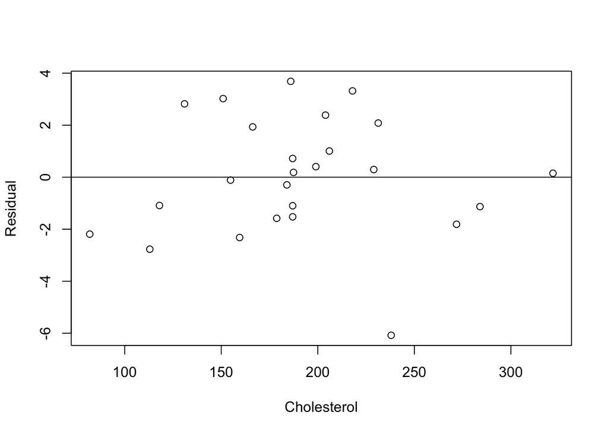

```r
plot(bmiregd1$residual, x = d1$chl, xlab = "Cholesterol", ylab = "Residual")
abline(0,0)
```

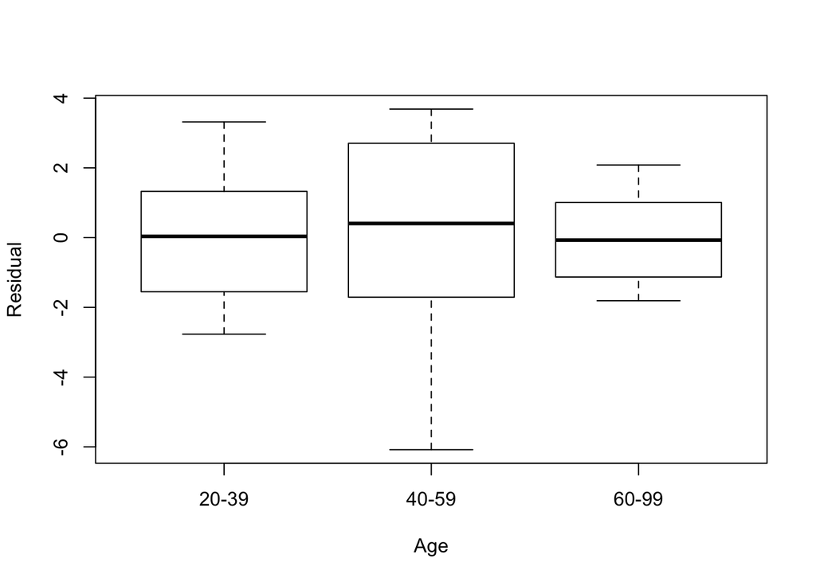

```r
boxplot(bmiregd1$residual ~ d1$age, xlab = "Age", ylab = "Residual")
```

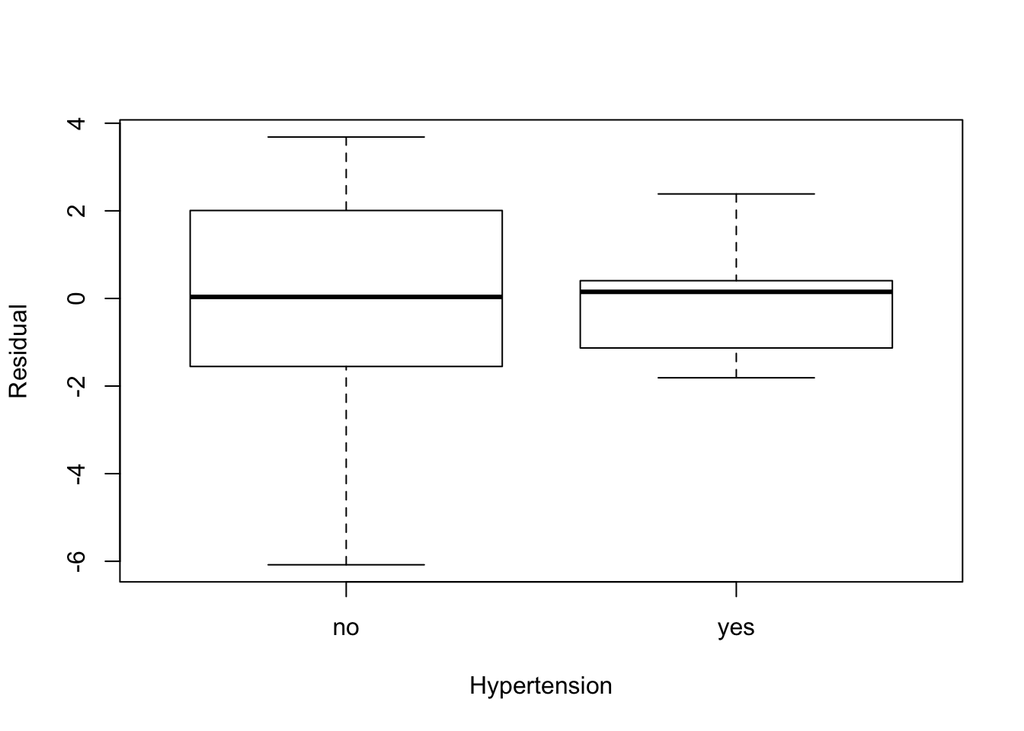

```r
boxplot(bmiregd1$residual ~ d1$hyp, xlab = "Hypertension", ylab = "Residual")
```

Pretty reasonable residual plots. A good idea is to repeat this for more than one completed dataset. If you decide transformations are needed, you might reconsider the imputation models too and fit them with transformed values.

If you want to do multiple imputation inferences on all `m=5` data sets, use the `with` command. For example, to fit a **linear regression** of `bmi` on `age + hyp + chl`:

```r
bmiregMI5 = with(data=nhanes2MI5, lm(bmi~age+hyp+chl))
summary(bmiregMI5)
```

```
## # A tibble: 25 x 5
##    term        estimate std.error statistic    p.value
##    <chr>          <dbl>     <dbl>     <dbl>      <dbl>
##  1 (Intercept)  13.7       2.37       5.77  0.0000121
##  2 age40-59     -5.58      1.27      -4.41  0.000269
##  3 age60-99    -10.3       1.67      -6.15  0.00000527
##  4 hypyes        1.09      1.63       0.670 0.511
##  5 chl           0.0839    0.0139     6.04  0.00000663
##  6 (Intercept)  12.3       2.44       5.06  0.0000601
##  7 age40-59     -5.97      1.46      -4.08  0.000581
##  8 age60-99    -11.9       1.74      -6.82  0.00000124
##  9 hypyes        0.350     1.53       0.229 0.822
## 10 chl           0.0955    0.0143     6.66  0.00000176
## # ... with 15 more rows
```

To get the **multiple imputation inferences** based on the Rubin (1987) combining rules – see the slides – use the `pool` command:

```r
bmireg = pool(bmiregMI5)
summary(bmireg)
```

```
##                estimate  std.error  statistic       df     p.value
## (Intercept)  14.1840605 3.96739391  3.5751581 5.194110 0.007687387
## age40-59     -6.6797335 1.87964387 -3.5537229 7.713681 0.007925676
## age60-99    -12.1435283 2.63248828 -4.6129468 5.433678 0.001898904
## hypyes        2.0346388 2.13133658  0.9546305 7.110528 0.368718755
## chl           0.0854122 0.02096924  4.0732134 6.743999 0.003852516
```

If you want to do a **nested F test** (well, technically a test that is asymptotically equivalent to a nested F test), then use `pool.compare`. Suppose we want to see if `age` is a useful predictor. We have to redo the with-age regression to have `age` as the last predictor.

```r
bmiregMI5 = with(data=nhanes2MI5, lm(bmi~hyp+chl+age))
bmiregMI5noage = with(data=nhanes2MI5, lm(bmi~hyp+chl))
pool.compare(bmiregMI5, bmiregMI5noage)
```

```
## $call
## pool.compare(fit1 = bmiregMI5, fit0 = bmiregMI5noage)
##
## $call11
## with.mids(data = nhanes2MI5, expr = lm(bmi ~ hyp + chl + age))
##
## $call12
## mice(data = nhanes2, m = 5, defaultMethod = c("norm", "logreg",
##     "polyreg", "polr"))
##
## $call01
## with.mids(data = nhanes2MI5, expr = lm(bmi ~ hyp + chl))
##
## $call02
## mice(data = nhanes2, m = 5, defaultMethod = c("norm", "logreg",
##     "polyreg", "polr"))
##
## $method
## [1] "wald"
##
## $nmis
## age bmi hyp chl
##   0   9   8  10
##
## $m
## [1] 5
##
## $qbar1
## (Intercept)      hypyes         chl    age40-59    age60-99
##  14.1840605   2.0346388   0.0854122  -6.6797335 -12.1435283
##
## $qbar0
## (Intercept)      hypyes         chl
## 20.48011951 -0.51088587  0.03075059
##
## $ubar1
## [1] 7.2233187839 2.6090856965 0.0002439248 2.1363015527 3.2939027614
##
## $ubar0
## [1] 1.832516e+01 7.286680e+00 5.266938e-04
##
## $deviances
## NULL
##
## $Dm
##          [,1]
## [1,] 17.47214
##
## $rm
## [1] 0.8788535
##
## $df1
## [1] 2
##
## $df2
## [1] 17.74014
##
## $pvalue
##              [,1]
## [1,] 6.410541e-05
```

You also can fit **logistic regressions**. For example to predict hypertension from all the other variables, use:

```r
hyplogregMI5 = with(data=nhanes2MI5, glm(hyp~bmi+chl+age, family = binomial))
hyplogreg = pool(hyplogregMI5)
summary(hyplogreg)
```

```
##                 estimate   std.error     statistic       df   p.value
## (Intercept) -3759.574521   824933.72 -4.557426e-03 18.25904 0.9964131
## bmi            65.363442    14284.78  4.575741e-03 18.25904 0.9963987
## chl             6.585068     1471.53  4.474981e-03 18.25904 0.9964780
## age40-59      736.660721   162896.64  4.522259e-03 18.25904 0.9964408
## age60-99      411.603822 12252744.44  3.359279e-05 18.25904 0.9999736
```

This turns out to be problematic because we have some logistic regressions with perfect predictions.  
We do not have enough data to do a meaningful logistic regression here, unless we drop `age` as a predictor. But the command structure is fine.